# An Introduction to Machine Learning

## Alex Pizzuto

*IceCube Bootcamp: June 2019*  
*WIPAC / UW-Madison*

*GitHub repo with materials:* https://github.com/apizzuto/bootcamp-machine-learning

*Lots of material in these slides are from talks on ML by James Bourbeau or Sebastian Raschka

# Outline

- What is Machine Learning?
  - Machine Learning vs. Classical Programming
  - Supervised vs. Unsupervised Machine Learning
- Data Representation
- Machine Learning Algorithms
  - Tree Based Learning
- Model Validation
- Machine Learning in IceCube

## Machine Learning (ML)

"Machine Learning is the hot new thing"  
— John L. Hennessy, Stanford President

## Machine Learning (ML)

*Slightly* more seriously:  
"Machine learning is the field of study that gives computers the ability to learn without being explicitly programmed"  
— Arthur Samuel (Vanguard of AI)

"A machine-learning system is trained rather than explicitly programmed. It’s presented with many examples relevant to a task, and it finds statistical structure in these examples that eventually allows the system to come up with rules for automating the task."  
— Francois Chollet, *Deep Learning with Python*

## Classical Programming

Suppose we want to write an algorithm to classify messages as `spam` or `not spam`.  
The classical approach:

```python
def spam_filter(email):
    """Function that labels an email as 'spam' or 'not spam'
    """
    if 'Act now!' in email.contents:
        label = 'spam'
    elif 'hotmail.com' in email.sender:
        label = 'spam'
    elif email.contents.count('$') > 20:
        label = 'spam'
    else:
        label = 'not spam'

    return label
```

### The Machine Learning Approach

Provide an example of some emails

[figure not shown]

### The Machine Learning Approach

Provide an example of some emails  
Label them as spam or not spam  
Let the computer figure out the rules

[figure not shown]

## Types of ML

[figure not shown]

## Supervised Learning

Supervised learning is broken down into two categories, *Classification* and *Regression*

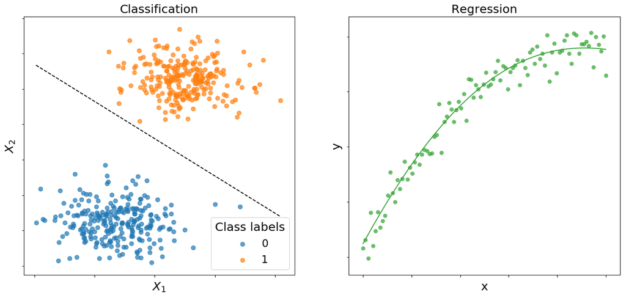

```python
plotting.plot_classification_vs_regression()
```

## Data Representation

We represent our data as a 2D array. Each row represents a *sample*, and each column represents a *feature*

Each sample has a correct classification, called a *target*, and we represent these as a column vector

[figure not shown]

## Training a model

First, you pick an model (algorithm) to use. You then pass the data to the model, and the model learns the parameters which best split your data

[figure not shown]

## Making Predictions

Once the model is trained, you can use it to predict targets on unseen data

[figure not shown]

## Algorithms

- More ML Algorithms Exist than I could talk about today
  - K-Nearest Neighbors: Search for clustering in data
  - Adaptive Linear Neurons: Building blocks for Deep Learning Algorithms
  - Support Vector Machines
  - Linear / Logistic Regression
  - Tree Based Learning
- Tree Based learning is the most popular in IceCube

# Tree Based Learning

## Tree Based Learning

[figure not shown]

## Features of decision tree classifier

- Easy to understand and interpretable model
- Requires little data preparation
- Can model non-linear relationships
- Building block for more advanced models (e.g. random forests, boosted decision trees)

## Constructing a decision tree: asking the right questions

To construct a decision tree, you just have to choose a quantity to maximize (or minimize)

Example: Choose the splitting that maximizes the *information gain*, $IG$;

$$ I G \left( S _ { p } , f \right) = I \left( S _ { p } \right) - \frac { N _ { 1 } } { N _ { p } } I \left( S _ { 1 } \right) - \frac { N _ { 2 } } { N _ { p } } I \left( S _ { 2 } \right) $$

where the impurity, $I$, is defined as

$$ I ( S ) = 1 - \sum _ { i = 1 } ^ { N _ { \mathrm { class } } } p ( i | S ) ^ { 2 } $$

[figure not shown]

## Constructing a decision tre

Continue doing this until each leaf is pure or until you've met other stop conditions

[figure not shown]

## Visualizing decision trees

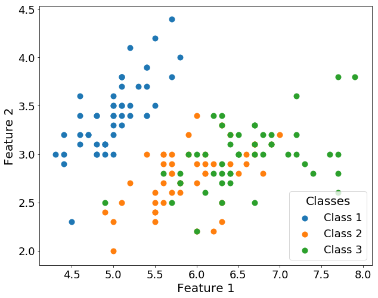

```python
plotting.plot_2D_iris()
```

## Visualizing decision trees

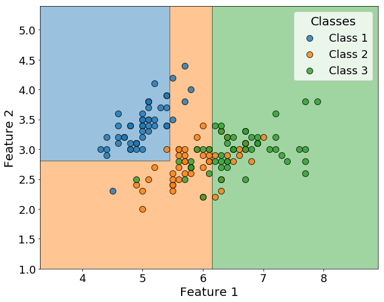

```python
plotting.plot_tree_decision_regions(clf)
```

## Ensemble Learning: Random Forests

Many times, individual algorithms (*weak learners*) are combined to create a more sophisticated algorithm

*Idea:* Combine many different decision trees to improve performance

1. Split up your training data into $n$ *bootstrap* samples
2. For each one of these samples, build a decision tree
   - Only use a subset of available features for each tree
3. Once all trees are built, classify testing data by majority vote from all your trees

Split up your training data into $n$ *bootstrap* samples

[figure not shown]

Split up your training data into $n$ *bootstrap* samples

[figure not shown]

For each one of these samples, build a decision tree

```
- Only use a subset of available features for each tree
```

[figure not shown]

Once all trees are built, classify testing data by majority vote from all your trees

[figure not shown]

## Ensemble Learning: Boosted Decision Trees

Boosted Decision Trees (BDTs) are similar to Random Forests, but they don't randomly draw "bootstrap" samples

Instead they find where the trees perform the *worst*, and *boost* the power of the next tree by weighting misclassifications more heavily

The result is a weighted average from many trees, instead of just a majority vote

[figure not shown]

## Model Validation

## Model Validation

You want a model that is complex enough to describe your data, but not too complex that it treats statistical fluctuations as meaningful.

- Under-fitting — model isn't sufficiently complex enough to properly model the dataset at hand
- Over-fitting — model is too complex and begins to learn the noise in the training dataset

[figure not shown]

Image source: [Underfitting vs. Overfitting](http://scikit-learn.org/stable/auto_examples/model_selection/plot_underfitting_overfitting.html) in scikit-learn examples

## Model validation: hyperparameter tuning

Parameters unique to the algorithm you are using are called *hyperparameters*.

Changing hyperparameters can make a model more or less complex

For BDTs or random forests, these include:

1. The depth of a tree
2. The total number of trees
3. Number of features considered in each tree

## Model validation: training & testing sets

- A trained model will generally perform better on data that was used to train it
- Want to measure how well a model generalizes to new, unseen data
- Need to have two separate datasets. One for training models and one for evaluating model performance

## Model validation: $k$-fold cross validation

[figure not shown]

Image source: Raschka, Sebastian, and Vahid Mirjalili. [Python Machine Learning](https://www.amazon.com/Python-Machine-Learning-scikit-learn-TensorFlow/dp/1787125939), 2nd Ed. Packt Publishing, 2017.

## Validation curves

Validation curves are a good way to diagnose if a model is under- or over-fitting

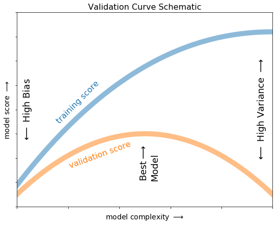

```python
plotting.plot_validation_curve()
```

## IceCube Use Cases

- BDTs: Event selections
- BDTs: Low-Energy Particle Identification
- Random Forests: Angular Error Estimation
- Deep Learning: Event Reconstructions

[figure not shown]

## Additional Resources

- Notebook that works through decision tree and Random forest examples: [GitHub](https://github.com/apizzuto/bootcamp-machine-learning/blob/master/decision_trees_and_nearest_neighbors.ipynb)
- *Python Machine Learning* by Sebastian Raschka: [GitHub](https://github.com/rasbt/python-machine-learning-book-2nd-edition)
- *Data Science Handbook* by Jake VanderPlas: [GitHub](https://github.com/jakevdp/PythonDataScienceHandbook)
- *The Elements of Statistical Learning* by Hastie, Tibshirani and Friedman: [Free Book](https://web.stanford.edu/~hastie/ElemStatLearn/)
- *Deep Learning* by Ian Goodfellow, Yoshua Bengio, and Aaron Courville: [Amazon](https://www.amazon.com/Deep-Learning-Adaptive-Computation-Machine/dp/0262035618)